# Project: TMDb movie data

Fatema Buhuligah

- Introduction
- Data Wrangling
- Exploratory Data Analysis
- Conclusions

## Introduction

I will investigate and analyze the TMDb movies dataset (cleaned from original data on Kaggle) on different properties of 10,000 movie samples.

I will answer these questions in my analysis process:

1. What is the most common movie genre produced in this dataset?
2. Do movies with longger runtime receive better rating?
3. Which year is associated with the higher rating?
4. How many movies produced in each year?

To start investigating these questions, first I have to import all the package that I will use in this project.

```python
import pandas as pd
import numpy as np
import matplotlib.pyplot as plt
import seaborn as sns

%matplotlib inline
```

## Data Wrangling

Then, I will load the dataset and assess it to identify any problems and make sure it is cleaned and in a great quality for the analysis process.

### General Properties

```python
df = pd.read_csv('tmdb-movies.csv');
df.head()
```

|  | id | imdb_id | popularity | budget | revenue | original_title | cast | homepage | director | tagline | ... | overview | runtime | genres | production_companies | release_date | vote_count | vote_average | release_year | budget_adj | revenue_adj |
| --- | --- | --- | --- | --- | --- | --- | --- | --- | --- | --- | --- | --- | --- | --- | --- | --- | --- | --- | --- | --- | --- |
| 0 | 135397 | tt0369610 | 32.985763 | 150000000 | 1513528810 | Jurassic World | Chris Pratt\|Bryce Dallas Howard\|Irrfan Khan\|Vi... | http://www.jurassicworld.com/ | Colin Trevorrow | The park is open. | ... | Twenty-two years after the events of Jurassic ... | 124 | Action\|Adventure\|Science Fiction\|Thriller | Universal Studios\|Amblin Entertainment\|Legenda... | 6/9/15 | 5562 | 6.5 | 2015 | 1.379999e+08 | 1.392446e+09 |
| 1 | 76341 | tt1392190 | 28.419936 | 150000000 | 378436354 | Mad Max: Fury Road | Tom Hardy\|Charlize Theron\|Hugh Keays-Byrne\|Nic... | http://www.madmaxmovie.com/ | George Miller | What a Lovely Day. | ... | An apocalyptic story set in the furthest reach... | 120 | Action\|Adventure\|Science Fiction\|Thriller | Village Roadshow Pictures\|Kennedy Miller Produ... | 5/13/15 | 6185 | 7.1 | 2015 | 1.379999e+08 | 3.481613e+08 |
| 2 | 262500 | tt2908446 | 13.112507 | 110000000 | 295238201 | Insurgent | Shailene Woodley\|Theo James\|Kate Winslet\|Ansel... | http://www.thedivergentseries.movie/#insurgent | Robert Schwentke | One Choice Can Destroy You | ... | Beatrice Prior must confront her inner demons ... | 119 | Adventure\|Science Fiction\|Thriller | Summit Entertainment\|Mandeville Films\|Red Wago... | 3/18/15 | 2480 | 6.3 | 2015 | 1.012000e+08 | 2.716190e+08 |
| 3 | 140607 | tt2488496 | 11.173104 | 200000000 | 2068178225 | Star Wars: The Force Awakens | Harrison Ford\|Mark Hamill\|Carrie Fisher\|Adam D... | http://www.starwars.com/films/star-wars-episod... | J.J. Abrams | Every generation has a story. | ... | Thirty years after defeating the Galactic Empi... | 136 | Action\|Adventure\|Science Fiction\|Fantasy | Lucasfilm\|Truenorth Productions\|Bad Robot | 12/15/15 | 5292 | 7.5 | 2015 | 1.839999e+08 | 1.902723e+09 |
| 4 | 168259 | tt2820852 | 9.335014 | 190000000 | 1506249360 | Furious 7 | Vin Diesel\|Paul Walker\|Jason Statham\|Michelle ... | http://www.furious7.com/ | James Wan | Vengeance Hits Home | ... | Deckard Shaw seeks revenge against Dominic Tor... | 137 | Action\|Crime\|Thriller | Universal Pictures\|Original Film\|Media Rights ... | 4/1/15 | 2947 | 7.3 | 2015 | 1.747999e+08 | 1.385749e+09 |

5 rows × 21 columns

#### Attribute Information

1. Id
2. imdb_id
3. popularity
4. budget
5. revenue
6. original_title
7. cast
8. homepage
9. director
10. tagline
11. keywords
12. overview
13. runtime
14. genres
15. production_companies
16. release_date
17. vote_count
18. vote_average
19. release_year
20. budget_adj (show the budget of the associated movie in terms of 2010 dollars, accounting for inflation over time.)
21. revenue_adj (show the revenue of the associated movie in terms of 2010 dollars, accounting for inflation over time.)

```python
df.shape
```

```
(10866, 21)
```

```python
df.describe()
```

|  | id | popularity | budget | revenue | runtime | vote_count | vote_average | release_year | budget_adj | revenue_adj |
| --- | --- | --- | --- | --- | --- | --- | --- | --- | --- | --- |
| count | 10866.000000 | 10866.000000 | 1.086600e+04 | 1.086600e+04 | 10866.000000 | 10866.000000 | 10866.000000 | 10866.000000 | 1.086600e+04 | 1.086600e+04 |
| mean | 66064.177434 | 0.646441 | 1.462570e+07 | 3.982332e+07 | 102.070863 | 217.389748 | 5.974922 | 2001.322658 | 1.755104e+07 | 5.136436e+07 |
| std | 92130.136561 | 1.000185 | 3.091321e+07 | 1.170035e+08 | 31.381405 | 575.619058 | 0.935142 | 12.812941 | 3.430616e+07 | 1.446325e+08 |
| min | 5.000000 | 0.000065 | 0.000000e+00 | 0.000000e+00 | 0.000000 | 10.000000 | 1.500000 | 1960.000000 | 0.000000e+00 | 0.000000e+00 |
| 25% | 10596.250000 | 0.207583 | 0.000000e+00 | 0.000000e+00 | 90.000000 | 17.000000 | 5.400000 | 1995.000000 | 0.000000e+00 | 0.000000e+00 |
| 50% | 20669.000000 | 0.383856 | 0.000000e+00 | 0.000000e+00 | 99.000000 | 38.000000 | 6.000000 | 2006.000000 | 0.000000e+00 | 0.000000e+00 |
| 75% | 75610.000000 | 0.713817 | 1.500000e+07 | 2.400000e+07 | 111.000000 | 145.750000 | 6.600000 | 2011.000000 | 2.085325e+07 | 3.369710e+07 |
| max | 417859.000000 | 32.985763 | 4.250000e+08 | 2.781506e+09 | 900.000000 | 9767.000000 | 9.200000 | 2015.000000 | 4.250000e+08 | 2.827124e+09 |

```python
df.info()
```

```
<class 'pandas.core.frame.DataFrame'>
RangeIndex: 10866 entries, 0 to 10865
Data columns (total 21 columns):
id                      10866 non-null int64
imdb_id                 10856 non-null object
popularity              10866 non-null float64
budget                  10866 non-null int64
revenue                 10866 non-null int64
original_title          10866 non-null object
cast                    10790 non-null object
homepage                2936 non-null object
director                10822 non-null object
tagline                 8042 non-null object
keywords                9373 non-null object
overview                10862 non-null object
runtime                 10866 non-null int64
genres                  10843 non-null object
production_companies    9836 non-null object
release_date            10866 non-null object
vote_count              10866 non-null int64
vote_average            10866 non-null float64
release_year            10866 non-null int64
budget_adj              10866 non-null float64
revenue_adj             10866 non-null float64
dtypes: float64(4), int64(6), object(11)
memory usage: 1.7+ MB
```

**In the previous code cells I used three functions (.shape , .describe and .info).**

shape

As the output of the shape function, I found there are 10866 movies (rows) in this dataset and 21 columns.

describe

The output of this function shows the statistical summary of the dataset.  
When observing the output some of the numbers does not make sense. For that I can identify the changes I will make to clean the data

info

In this function I can find a summary of the data in the columns, how many data are there, the missing data and the data type.

### Data Cleaning

In this section I will clean the dataset to insure it is in high quality as I need in my analysis process. I will use drop function to remove the columns that I won’t use.

**The columns are:** id, imdb_id, budget, revenue, popularity, cast, homepage, director, tagline, keywords, overview, production_companies, release_date, vote_count, budget_adj and revenue_adj.

**Reasons of removing:**

1. For both IDs colummns, cast, homepage, director, tagline, keywords, overview and production_companies these data are specific to the movies.
2. For released_date I will be contented with the released_year instead of the date.
3. For the budget, revenue, budget_adj and revenue_adj, (I looked at my dataset in excel sheet, and I found that there are more than 6000 movies with '0' value in these 4 columns).

```python
df.drop(['id','imdb_id', 'budget','revenue','popularity','cast','homepage','director','tagline','keywords','overview', 'production_companies','release_date','vote_count','budget_adj','revenue_adj'] , axis=1, inplace=True)
```

```python
df.head()
```

|  | original_title | runtime | genres | vote_average | release_year |
| --- | --- | --- | --- | --- | --- |
| 0 | Jurassic World | 124 | Action\|Adventure\|Science Fiction\|Thriller | 6.5 | 2015 |
| 1 | Mad Max: Fury Road | 120 | Action\|Adventure\|Science Fiction\|Thriller | 7.1 | 2015 |
| 2 | Insurgent | 119 | Adventure\|Science Fiction\|Thriller | 6.3 | 2015 |
| 3 | Star Wars: The Force Awakens | 136 | Action\|Adventure\|Science Fiction\|Fantasy | 7.5 | 2015 |
| 4 | Furious 7 | 137 | Action\|Crime\|Thriller | 7.3 | 2015 |

```python
df.info()
```

```
<class 'pandas.core.frame.DataFrame'>
RangeIndex: 10866 entries, 0 to 10865
Data columns (total 5 columns):
original_title    10866 non-null object
runtime           10866 non-null int64
genres            10843 non-null object
vote_average      10866 non-null float64
release_year      10866 non-null int64
dtypes: float64(1), int64(2), object(2)
memory usage: 424.5+ KB
```

**Based on the above output, I will need to do more of cleaning. This time I will clean some rows since there are some missing data.**

```python
df[df.genres.isnull()]
```

|  | original_title | runtime | genres | vote_average | release_year |
| --- | --- | --- | --- | --- | --- |
| 424 | Belli di papÃ | 100 | NaN | 6.1 | 2015 |
| 620 | All Hallows' Eve 2 | 90 | NaN | 5.0 | 2015 |
| 997 | Star Wars Rebels: Spark of Rebellion | 44 | NaN | 6.8 | 2014 |
| 1712 | Prayers for Bobby | 88 | NaN | 7.4 | 2009 |
| 1897 | Jonas Brothers: The Concert Experience | 76 | NaN | 7.0 | 2009 |
| 2370 | Freshman Father | 0 | NaN | 5.8 | 2010 |
| 2376 | Doctor Who: A Christmas Carol | 62 | NaN | 7.7 | 2010 |
| 2853 | Vizontele | 110 | NaN | 7.2 | 2001 |
| 3279 | ì•„ê¸°ì™€ ë‚˜ | 96 | NaN | 6.1 | 2008 |
| 4547 | London 2012 Olympic Opening Ceremony: Isles of... | 220 | NaN | 8.3 | 2012 |
| 4732 | The Scapegoat | 100 | NaN | 6.2 | 2012 |
| 4797 | Doctor Who: The Snowmen | 60 | NaN | 7.8 | 2012 |
| 4890 | Cousin Ben Troop Screening | 2 | NaN | 7.0 | 2012 |
| 5830 | Doctor Who: The Time of the Doctor | 60 | NaN | 8.5 | 2013 |
| 5934 | Prada: Candy | 3 | NaN | 6.9 | 2013 |
| 6043 | Bombay Talkies | 127 | NaN | 5.9 | 2013 |
| 6530 | Saw Rebirth | 6 | NaN | 5.9 | 2005 |
| 8234 | Viaggi di nozze | 103 | NaN | 6.7 | 1995 |
| 8614 | T2 3-D: Battle Across Time | 12 | NaN | 6.7 | 1996 |
| 8878 | Mom's Got a Date With a Vampire | 85 | NaN | 5.4 | 2000 |
| 9307 | Goldeneye | 105 | NaN | 5.3 | 1989 |
| 9799 | The Amputee | 5 | NaN | 5.0 | 1974 |
| 10659 | The Party at Kitty and Stud's | 71 | NaN | 3.0 | 1970 |

There are 23 rows with missing data in genres columns, I will drop these rows.

```python
df.dropna(inplace=True)
df.info()
```

```
<class 'pandas.core.frame.DataFrame'>
Int64Index: 10843 entries, 0 to 10865
Data columns (total 5 columns):
original_title    10843 non-null object
runtime           10843 non-null int64
genres            10843 non-null object
vote_average      10843 non-null float64
release_year      10843 non-null int64
dtypes: float64(1), int64(2), object(2)
memory usage: 508.3+ KB
```

```python
df.loc[df['runtime'] == 0 ]

# I noticed in the output of the describe function the minmmum of runtime is 0, which does not make sence.
# This code will show me the movies with 0 runtime. For cleaning the data I'll remove these movies.
```

|  | original_title | runtime | genres | vote_average | release_year |
| --- | --- | --- | --- | --- | --- |
| 92 | Mythica: The Necromancer | 0 | Fantasy\|Action\|Adventure | 5.4 | 2015 |
| 334 | Ronaldo | 0 | Documentary | 6.5 | 2015 |
| 410 | Anarchy Parlor | 0 | Horror | 5.6 | 2015 |
| 445 | The Exorcism of Molly Hartley | 0 | Horror | 5.0 | 2015 |
| 486 | If There Be Thorns | 0 | TV Movie\|Drama | 5.4 | 2015 |
| 595 | Deep Dark | 0 | Horror | 4.6 | 2015 |
| 616 | The Outfield | 0 | Drama\|Comedy | 6.6 | 2015 |
| 1241 | Dance-Off | 0 | Romance\|Music\|Comedy | 5.7 | 2014 |
| 1289 | Treehouse | 0 | Thriller\|Horror\|Mystery | 3.4 | 2014 |
| 1293 | Tim Maia | 0 | Documentary\|Drama\|Music | 6.0 | 2014 |
| 1849 | Spectacular! | 0 | Drama\|Music | 5.2 | 2009 |
| 2315 | Listen to Your Heart | 0 | Drama\|Music\|Romance | 7.3 | 2010 |
| 3329 | Grande, grosso e Verdone | 0 | Family | 5.3 | 2008 |
| 3794 | Toi, moi, les autres | 0 | Music\|Romance | 5.2 | 2011 |
| 3857 | Cell 213 | 0 | Horror | 5.2 | 2011 |
| 3884 | eCupid | 0 | Romance | 4.6 | 2011 |
| 4063 | Madea's Family Reunion | 0 | Comedy | 5.9 | 2002 |
| 4138 | A Time for Dancing | 0 | Drama\|Music | 7.5 | 2002 |
| 4829 | Rags | 0 | TV Movie\|Comedy\|Drama | 5.7 | 2012 |
| 4944 | How to Fall in Love | 0 | Comedy\|Romance\|TV Movie | 4.7 | 2012 |
| 5216 | Madea's Class Reunion | 0 | Comedy\|Music | 6.9 | 2003 |
| 5695 | Skinwalker Ranch | 0 | Thriller\|Horror\|Science Fiction | 4.3 | 2013 |
| 5920 | The Food Guide to Love | 0 | Romance\|Comedy | 5.6 | 2013 |
| 5938 | Go Goa Gone | 0 | Comedy\|Horror | 5.3 | 2013 |
| 5992 | Amiche da morire | 0 | Romance\|Crime\|Comedy | 5.5 | 2013 |
| 6040 | The Vatican Exorcisms | 0 | Horror\|Documentary\|Mystery | 4.7 | 2013 |
| 6383 | The 12 Dogs of Christmas | 0 | Drama\|Family | 4.7 | 2005 |
| 6552 | Quatre Ã©toiles | 0 | Comedy | 5.9 | 2005 |
| 6934 | Jean-Philippe | 0 | Comedy | 5.6 | 2006 |
| 8874 | Mission Kashmir | 0 | Action\|Drama\|Foreign | 5.7 | 2000 |

```python
df = df[df.runtime != 0]

# I used this code based on this site (https://stackoverflow.com/questions/18172851/deleting-dataframe-row-in-pandas-based-on-column-value)
# To delet all the movies with the runtime = 0
```

```python
sum(df.duplicated())
# I used .duplicated function to find if there is any duplicated row
```

```
1
```

```python
df.drop_duplicates(inplace=True)
print(df.shape)

#Here I removed the duplicated row
```

```
(10812, 5)
```

```python
df.info()
```

```
<class 'pandas.core.frame.DataFrame'>
Int64Index: 10812 entries, 0 to 10865
Data columns (total 5 columns):
original_title    10812 non-null object
runtime           10812 non-null int64
genres            10812 non-null object
vote_average      10812 non-null float64
release_year      10812 non-null int64
dtypes: float64(1), int64(2), object(2)
memory usage: 506.8+ KB
```

My dataset is cleaned, I will start next step. I ended up with 10812 rows and 5 columns.

## Exploratory Data Analysis

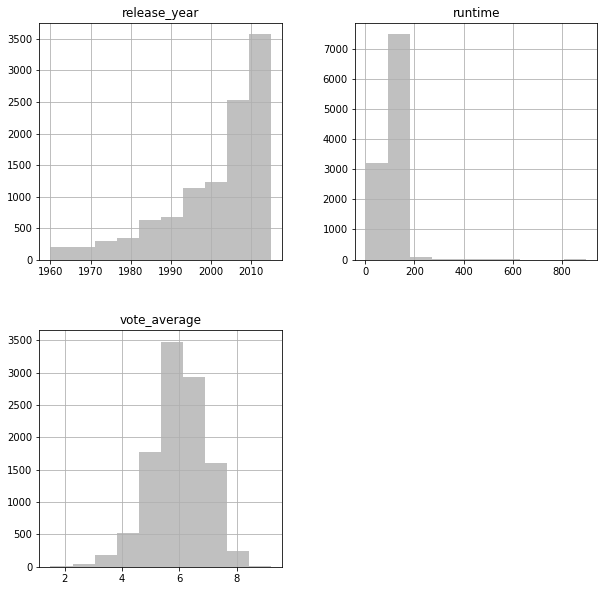

```python
df.hist(figsize=(10,10), color='silver');
```

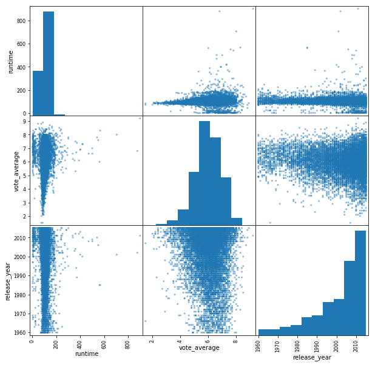

```python
pd.plotting.scatter_matrix(df, figsize=(10,10));
```

### Question 1: What is the most common movie genre produced in this dataset?

For this question, I have to split the genres columns sinces it has multiple values in the same cell. I followed the steps of this document:(https://static1.squarespace.com/static/55bfa8e4e4b007976149574e/t/5b998f398a922d8eaecaefd2/1536790332004/investigate-dataset-movies.pdf), to get a copy of my dataframe and then split the genres column into several rows (to show each genre indviually) then remove the genres column with the multiple values.

```python
df_genre = df.copy()
genre = df_genre['genres'].str.split('|').apply(pd.Series, 1).stack().reset_index(level=1, drop=True)
genre.name = 'genre'
df_genre = df_genre.drop(['genres'], axis=1).join(genre)
```

```python
df_genre.to_csv('tmbd-movies-genres.csv')
```

```python
df_genre.head()
```

|  | original_title | runtime | vote_average | release_year | genre |
| --- | --- | --- | --- | --- | --- |
| 0 | Jurassic World | 124 | 6.5 | 2015 | Action |
| 0 | Jurassic World | 124 | 6.5 | 2015 | Adventure |
| 0 | Jurassic World | 124 | 6.5 | 2015 | Science Fiction |
| 0 | Jurassic World | 124 | 6.5 | 2015 | Thriller |
| 1 | Mad Max: Fury Road | 120 | 7.1 | 2015 | Action |

**in the previous code cells,** after splitting the genres and dropping the genres with multiple values, I saved the new dataframe. As the output of the head function shows that, one movie has the same index number with multiple rows for different value in the genre column.

```python
df_genre['genre'].value_counts()
```

```
Drama              4751
Comedy             3782
Thriller           2905
Action             2382
Romance            1705
Horror             1629
Adventure          1470
Crime              1353
Family             1229
Science Fiction    1228
Fantasy             915
Mystery             808
Animation           699
Documentary         517
Music               401
History             334
War                 270
Foreign             187
Western             165
TV Movie            164
Name: genre, dtype: int64
```

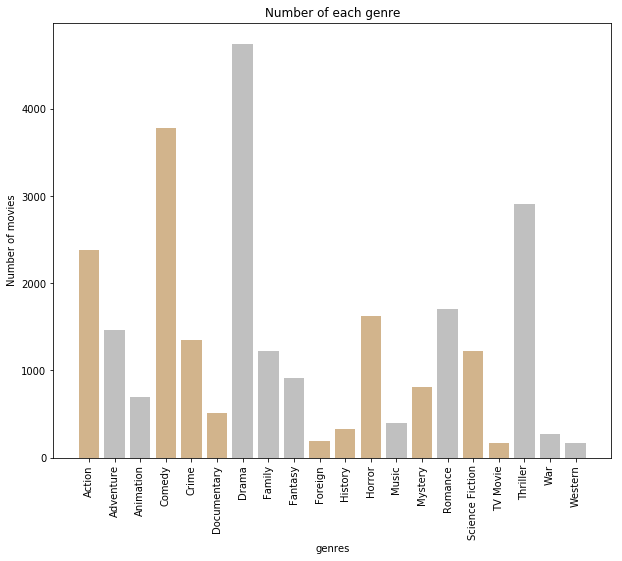

```python
x = ['Drama','Comedy','Thriller','Action','Romance','Horror','Adventure','Crime','Family','Science Fiction','Fantasy','Mystery','Animation','Documentary','Music','History','War','Foreign','Western','TV Movie']
y = [4751,3782,2905,2382,1705,1629,1470,1353,1229,1228,915,808,699,517,401,334,270,187,165,164]

plt.figure(figsize=(10,8))
plt.xticks(rotation=90)

plt.bar(x, y,color=['silver','tan'])

plt.title('Number of each genre')
plt.xlabel('genres')
plt.ylabel('Number of movies');
```

From the bar chart, I found that the most common movie genre produced in this dataset is **Drama genre.**

### Question 2: Do movies with longger runtime receive better rating?

```python
median = df['runtime'].median()
short = df.query('runtime < {}'.format(median))
long = df.query('runtime >= {}'.format(median))

vote_average_low = short['vote_average'].mean()
vote_average_high = long['vote_average'].mean()
```

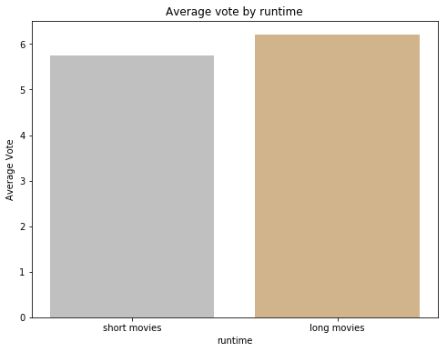

```python
locations = [1, 2]
heights = [vote_average_low, vote_average_high]
labels = ['short movies', 'long movies']
plt.figure(figsize=(8,6))
plt.bar(locations, heights, tick_label=labels,color=['silver', 'tan'])
plt.title('Average vote by runtime')
plt.xlabel('runtime')
plt.ylabel('Average Vote');
```

**The bar chart above shows that the movies with longger runtime receive higher rating,** I followed the same steps in the first case study (19.Plotting with Matplotlib). by using query to group the two types of movies runtime as (short runtime and long runtime) through the median, then compare it to the mean of the 'vote_average'.

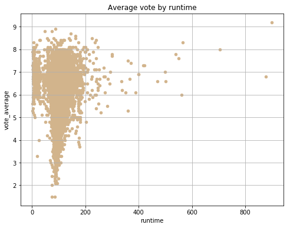

```python
df.plot(x='runtime', y='vote_average', kind='scatter',figsize=(8,6), color='tan', grid=True , title='Average vote by runtime');
```

**I also applied another kind of plots (scatter),** it appears that the longest movie reciecved the highest rating overall.

### Question 3: Which year is associated with the higher rating?

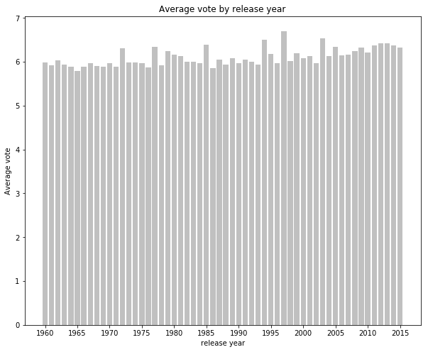

```python
years_vote_means = df.groupby('release_year').vote_average.mean()
x = df.release_year.unique()
y = years_vote_means
plt.figure(figsize=(10,8))
plt.xticks([1960,1965,1970,1975,1980,1985,1990,1995,2000,2005,2010,2015])
plt.bar(x, y,color=['silver'])
plt.title('Average vote by release year')
plt.xlabel('release year')
plt.ylabel('Average vote');
```

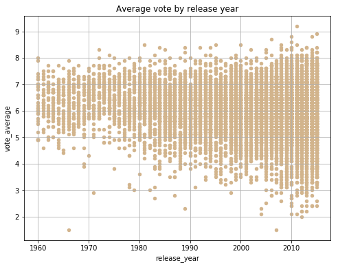

```python
df.plot(x='release_year', y='vote_average', kind='scatter',figsize=(8,6), color='tan', grid=True , title="Average vote by release year");
```

**I also applied another kind of plots (scatter),** it appears that the highest rate movie produced in 2011.

### Question 4: How many movies produced in each year?

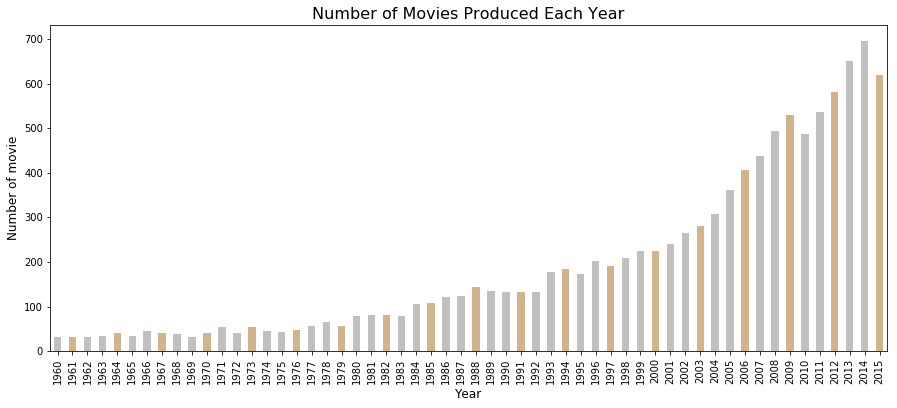

```python
Movie_counts = df.groupby(['release_year']).count()['original_title'].plot(kind='bar', color=['silver','tan'], figsize=(15,6))
plt.title('Number of Movies Produced Each Year', size=16)
plt.xlabel('Year',size=12)
plt.ylabel('Number of movie',size=12);
Movie_counts;
```

**In the above bar chart,** it shows the number of movies produced each year. So, the year with the highest number of movies produced is **2014**. Overall, it shows that the production of movies is getting increased over time.

## Conclusions

*I investigated and analyzed a dataset of approximatly 10,000 movies, from the TMDb from the Kaggle.*

**1. Data Wrangling**

- I observe the dataset from the excel sheet (csv) and found in the (budget, revenue, budget_adj and revenue_adj) columns there are a lot of ('0' zero values) which don't make sence.
- Also, the info() function showed the missing data. So, I cleand the data, and based on the questions I posed, I dropped the columns that I did not need in my analysis process.
- Moreover, there were some rows with NaN value in genres column, some with 0 value in runtime column and a duplicated row. So I removed those rows.

**References**

```python
from subprocess import call
call(['python', '-m', 'nbconvert', 'Project 2 TMDb movie data.ipynb'])
```

```
0
```